# Statistical testing of alpha diversity

Mateu Menendez Serra (mateu.menendez@sund.ku.dk)

2026-05-27

Statistical testing of alpha diversity

# Overview

In this session, we will continue working with the same phyloseq object created in the previous practical and use phyloseq’s built-in functions to explore patterns of **alpha diversity** across samples.

Alpha diversity describes the diversity observed **within individual samples**. Unlike beta diversity, which focuses on differences between samples, alpha diversity summarises how complex or diverse a single microbial community is.

In this practical, we will focus on two commonly used alpha-diversity metrics:

- **Observed richness**: the number of detected MAGs or taxa within a sample.
- **Shannon diversity**: a metric that accounts for both richness and the evenness of abundance distributions.

Throughout the session, we will move from simple exploratory visualisations to formal statistical testing.

# 1. Load the phyloseq object

This practical assumes that you already created a phyloseq object in the previous session and saved it as an `.rds` file. We will load that object here so that everyone starts from the same point.

```r
library(phyloseq)
library(tidyverse)
library(tibble)
```

```r
ps <- readRDS(file.path("../data", "phyloseq_augmented_v2.rds"))

ps
```

```
## phyloseq-class experiment-level object
## otu_table()   OTU Table:         [ 173 taxa and 30 samples ]
## sample_data() Sample Data:       [ 30 samples by 5 sample variables ]
## tax_table()   Taxonomy Table:    [ 173 taxa by 7 taxonomic ranks ]
```

# 2. Alpha-diversity estimation

phyloseq provides convenient built-in functions to calculate and visualise alpha-diversity metrics directly from a phyloseq object.

The function `estimate_richness()` calculates alpha-diversity estimates for each sample, while `plot_richness()` provides quick visualisations of those estimates across samples or sample groups.

Both functions accept:

- a phyloseq object,
- and a vector specifying which diversity measures should be calculated.

In this session, we will focus on two of the most commonly used alpha-diversity metrics: Observed richness (`"Observed"`) and Shannon diversity (`"Shannon"`). These metrics capture different aspects of diversity and are therefore not interchangeable.

## Calculating alpha diversity

The function `estimate_richness()` calculates the selected diversity measures for every sample in the phyloseq object and returns the results as a data frame.

```r
# Calculate Shannon diversity for all samples
shannon <- estimate_richness(
  ps,
  measures = "Shannon"
)

head(shannon)
```

```
##             Shannon
## ERR2641635 3.897326
## ERR2641677 3.930367
## ERR2641733 4.015073
## SRR8692206 2.665166
## SRR8692207 2.065587
## SRR8692213 1.381900
```

## Visualising alpha diversity

The function `plot_richness()` creates quick exploratory visualisations of alpha-diversity patterns across samples. The simplest possible plot displays diversity values for each sample individually.

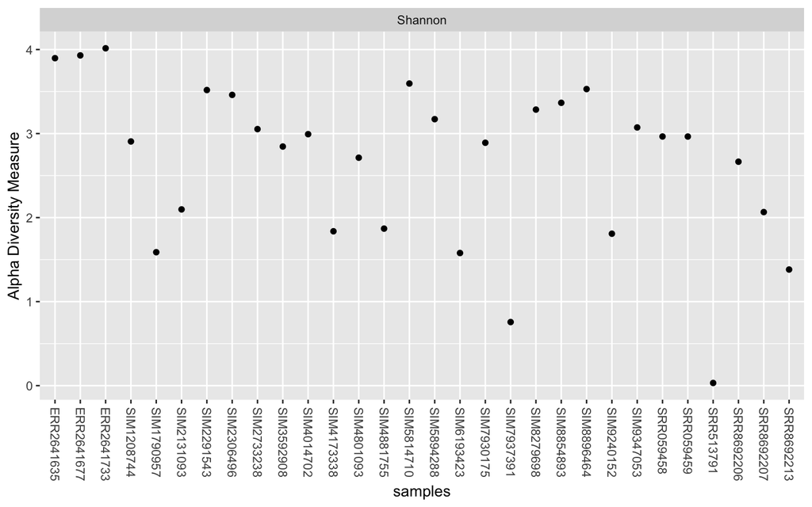

```r
plot_richness(
  ps,
  measures = "Shannon"
)
```

In many cases, we are interested in comparing diversity across groups of samples. Metadata variables stored in the phyloseq object can be used directly for grouping and visualisation.

Here, samples are grouped according to the `body_site` metadata variable.

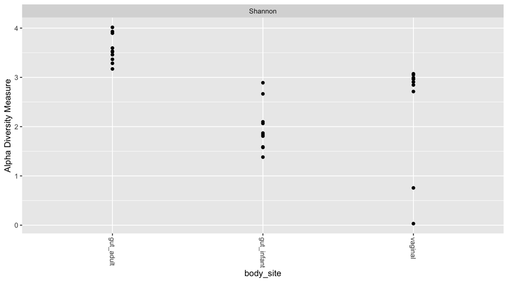

```r
plot_richness(
  ps,
  measures = "Shannon",
  x = "body_site"
)
```

Additional metadata variables can also be used to colour the points and facilitate interpretation.

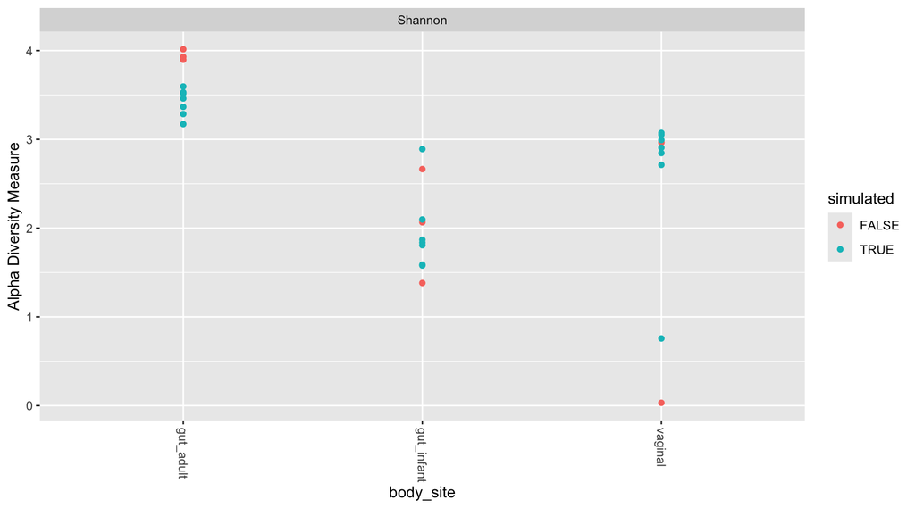

```r
plot_richness(
  ps,
  measures = "Shannon",
  x = "body_site",
  color = "simulated"
)
```

## Exercise: Observed richness

Now let us repeat the same exploration using **Observed richness** (`"Observed"`) instead of Shannon diversity.

Take a few minutes to create and inspect equivalent plots for observed richness, and think about how the patterns compare with the Shannon diversity plots.

Questions to consider:

- Do the same sample groups show higher or lower diversity?
- Are the differences between groups stronger or weaker than for Shannon diversity?

```r
# Calculate Observed richness for all samples
```

# 3. Statistical testing

The built-in `plot_richness()` function is very useful for quick exploratory visualisations, but in many analyses we also want to perform formal statistical testing to evaluate whether diversity differs significantly between groups of samples.

## Combining alpha-diversity estimates with sample metadata

To do this, it is often convenient to extract the alpha-diversity values into a standard data frame and combine them with the sample metadata stored in the phyloseq object.

The code below calculates both Shannon diversity and Observed richness separately, converts the sample names into an explicit column (`sample_id`), extracts the sample metadata, and finally merges everything into a single table.

```r
ps_pa <- transform_sample_counts(ps, function(x) {ifelse(x > 0, 1, 0)})

# Calculate Shannon diversity
shannon <- estimate_richness(
  ps,
  measures = "Shannon"
) %>%
  rownames_to_column("sample_id")

# Calculate observed richness
observed <- estimate_richness(
  ps_pa,
  measures = "Observed"
) %>%
  rownames_to_column("sample_id")

# Extract sample metadata
sample_df <- sample_data(ps) %>%
  data.frame() %>%
  rownames_to_column("sample_id")

# Combine diversity estimates and metadata
alpha_diversity <- inner_join(
  shannon,
  observed,
  by = "sample_id"
) %>%
  inner_join(
    sample_df,
    by = "sample_id"
  )
```

The resulting `alpha_diversity` data frame contains:

- one row per sample,
- alpha-diversity estimates,
- and all associated sample metadata variables.

This format is particularly useful because it allows us to use standard tidyverse and statistical functions for downstream analyses.

You can inspect the resulting table with:

```r
head(alpha_diversity)
```

```
##    sample_id  Shannon Observed  body_site simulated simulation_source_sample
## 1 ERR2641635 3.897326       77  gut_adult     FALSE                     <NA>
## 2 ERR2641677 3.930367       96  gut_adult     FALSE                     <NA>
## 3 ERR2641733 4.015073      108  gut_adult     FALSE                     <NA>
## 4 SRR8692206 2.665166       27 gut_infant     FALSE                     <NA>
## 5 SRR8692207 2.065587       33 gut_infant     FALSE                     <NA>
## 6 SRR8692213 1.381900       27 gut_infant     FALSE                     <NA>
##   simulation_source_group simulation_method
## 1                    <NA>              <NA>
## 2                    <NA>              <NA>
## 3                    <NA>              <NA>
## 4                    <NA>              <NA>
## 5                    <NA>              <NA>
## 6                    <NA>              <NA>
```

Now that all diversity estimates and metadata are combined into a single table, we can formally test whether alpha diversity differs between groups of samples.

A common first approach is to compare diversity across environments or sample types using statistical tests.

For example, we may want to ask:

*Do microbial communities from different body sites show significantly different alpha diversity?*

Before choosing a statistical test, it is important to remember that alpha-diversity values:

- are often not normally distributed,
- may contain unequal variances across groups,
- and can be strongly influenced by sequencing depth.

Because of this, non-parametric tests are frequently preferred in microbiome analyses.

In this practical, we will use the Kruskal-Wallis test, a non-parametric alternative to one-way ANOVA.

The Kruskal-Wallis test evaluates whether the distribution of diversity values differs across two or more groups.

## Testing Shannon diversity across body sites

```r
kruskal_shannon <- kruskal.test(
  Shannon ~ body_site,
  data = alpha_diversity
)

kruskal_shannon
```

```
##
##  Kruskal-Wallis rank sum test
##
## data:  Shannon by body_site
## Kruskal-Wallis chi-squared = 21.378, df = 2, p-value = 2.279e-05
```

The output includes a p-value that helps us evaluate whether alpha-diversity distributions differ across the groups being compared.

A small p-value, commonly below `0.05`, suggests evidence against the null hypothesis that all groups have similar diversity distributions, whereas a larger p-value indicates that the observed differences could plausibly arise by chance.

## Pairwise comparisons between groups

The Kruskal-Wallis test tells us whether there is evidence that diversity differs across groups overall, but it does not indicate which specific groups differ from each other.

To investigate this further, we can perform pairwise comparisons between all body-site groups using the Wilcoxon rank-sum test.

Because multiple comparisons are performed simultaneously, p-values should be adjusted to reduce the risk of false positives. Here, we use the Benjamini-Hochberg (`"BH"`) correction method.

```r
pw_shannon <- pairwise.wilcox.test(
  x = alpha_diversity$Shannon,
  g = alpha_diversity$body_site,
  p.adjust.method = "BH"
)

pw_shannon
```

```
##
##  Pairwise comparisons using Wilcoxon rank sum exact test
##
## data:  alpha_diversity$Shannon and alpha_diversity$body_site
##
##            gut_adult gut_infant
## gut_infant 1.6e-05   -
## vaginal    1.6e-05   0.035
##
## P value adjustment method: BH
```

The output is a matrix containing adjusted p-values for every pairwise comparison between body sites.

Interpretation guidelines:

- Small adjusted p-values suggest evidence that the diversity distributions differ between two specific groups.
- Larger p-values indicate weaker evidence for differences between those groups.
- Because p-values are adjusted for multiple testing, the results are more conservative than unadjusted pairwise tests.

This type of analysis is commonly used after a significant Kruskal-Wallis test, but it can also be informative as an exploratory analysis even when the global test is not significant.

## Visualising distributions with boxplots

Statistical tests are much easier to interpret when combined with visualisations.

A common approach is to display alpha-diversity distributions using boxplots together with individual sample points.

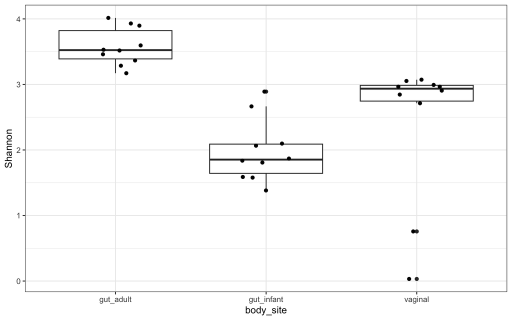

```r
ggplot(alpha_diversity, aes(x = body_site, y = Shannon)) +
  geom_boxplot() +
  geom_jitter(width = 0.2) +
  theme_bw()
```

## Exercise: Testing observed richness

Repeat the same analysis using Observed richness instead of Shannon diversity.

Tasks:

1. Perform a Kruskal-Wallis test for Observed richness across body sites.
2. Create a boxplot visualisation similar to the one above.
3. Compare the results obtained for Shannon diversity and Observed richness.

Questions to consider:

- Do both metrics lead to the same biological interpretation?
- Which metric shows stronger differences between body sites?
- Why might richness and Shannon diversity behave differently?

## Exercise: Effect of sequencing depth on alpha diversity

One important limitation of alpha-diversity estimation is that diversity metrics are often influenced by sequencing depth.

We can explore whether samples with more reads also tend to have higher diversity estimates.

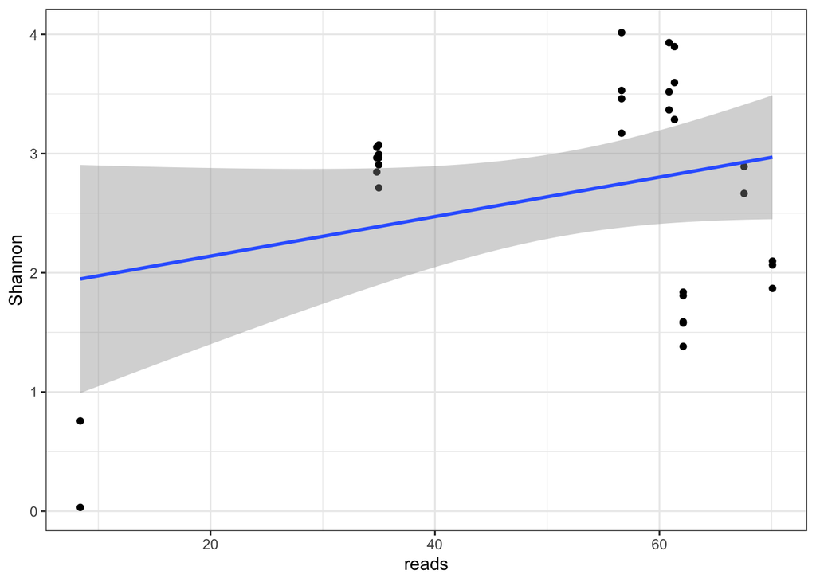

```r
# Total abundance per sample
sample_depth <- sample_sums(ps)

alpha_diversity$reads <- sample_depth[
  alpha_diversity$sample_id
]

ggplot(alpha_diversity, aes(x = reads, y = Shannon)) +
  geom_point() +
  geom_smooth(method = "lm") +
  theme_bw()
```

We can also test this relationship statistically.

```r
cor.test(
  alpha_diversity$reads,
  alpha_diversity$Shannon,
  method = "spearman"
)
```

```
##
##  Spearman's rank correlation rho
##
## data:  alpha_diversity$reads and alpha_diversity$Shannon
## S = 5260.7, p-value = 0.3681
## alternative hypothesis: true rho is not equal to 0
## sample estimates:
##        rho
## -0.1703407
```

Questions to consider:

- Do samples with more reads tend to show higher diversity?
- Is the relationship stronger for Observed richness or Shannon diversity?
- Why are richness metrics particularly sensitive to sequencing depth?